# 72 | 解释器模式：如何设计实现一个自定义接口告警规则功能？

[figure not shown]

# 72 | 解释器模式：如何设计实现一个自定义接口告警规则功能？

2020-04-17 王争

设计模式之美

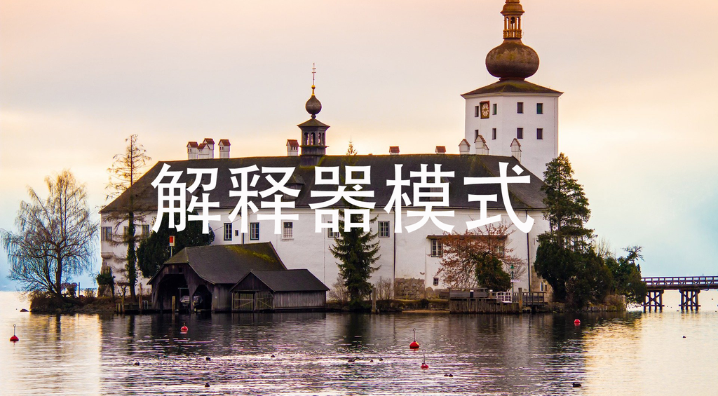

### 讲述：冯永吉

[interactive chart not shown]

上一节课，我们学习了命令模式。命令模式将请求封装成对象，方便作为函数参数传递和赋值给变量。它主要的应用场景是给命令的执行附加功能，换句话说，就是控制命令的执行，比如，排队、异步、延迟执行命令、给命令执行记录日志、撤销重做命令等等。总体上来讲，命令模式的应用范围并不广。

今天，我们来学习解释器模式，它用来描述如何构建一个简单的“语言”解释器。比起命令模式，解释器模式更加小众，只在一些特定的领域会被用到，比如编译器、规则引擎、正则表达式。所以，解释器模式也不是我们学习的重点，你稍微了解一下就可以了。

话不多说，让我们正式开始今天的学习吧！

## 解释器模式的原理和实现

解释器模式的英文翻译是 Interpreter Design Pattern。在 GoF 的《设计模式》一书中，它是这样定义的：

Interpreter pattern is used to defines a grammatical representation for a language and provides an interpreter to deal with this grammar.

翻译成中文就是：解释器模式为某个语言定义它的语法（或者叫文法）表示，并定义一个解释器用来处理这个语法。

看了定义，你估计会一头雾水，因为这里面有很多我们平时开发中很少接触的概念，比如“语言”“语法”“解释器”。实际上，这里的“语言”不仅仅指我们平时说的中、英、日、法等各种语言。从广义上来讲，只要是能承载信息的载体，我们都可以称之为“语言”，比如，古代的结绳记事、盲文、哑语、摩斯密码等。

要想了解“语言”表达的信息，我们就必须定义相应的语法规则。这样，书写者就可以根据语法规则来书写“句子”（专业点的叫法应该是“表达式”），阅读者根据语法规则来阅读“句子”，这样才能做到信息的正确传递。而我们要讲的解释器模式，其实就是用来实现根据语法规则解读“句子”的解释器。

为了让你更好地理解定义，我举一个比较贴近生活的例子来解释一下。

实际上，理解这个概念，我们可以类比中英文翻译。我们知道，把英文翻译成中文是有一定规则的。这个规则就是定义中的“语法”。我们开发一个类似 Google Translate 这样的翻译器，这个翻译器能够根据语法规则，将输入的中文翻译成英文。这里的翻译器就是解释器模式定义中的“解释器”。

刚刚翻译器这个例子比较贴近生活，现在，我们再举个更加贴近编程的例子。

假设我们定义了一个新的加减乘除计算“语言”，语法规则如下：

运算符只包含加、减、乘、除，并且没有优先级的概念；

表达式（也就是前面提到的“句子”）中，先书写数字，后书写运算符，空格隔开；

按照先后顺序，取出两个数字和一个运算符计算结果，结果重新放入数字的最头部位置，循环上述过程，直到只剩下一个数字，这个数字就是表达式最终的计算结果。

我们举个例子来解释一下上面的语法规则。

比如“ 8 3 2 4 - + * ”这样一个表达式，我们按照上面的语法规则来处理，取出数字“8 3”和“-”运算符，计算得到 5，于是表达式就变成了“ 5 2 4 + * ”。然后，我们再取出“ 5 2 ”和“ + ”运算符，计算得到 7，表达式就变成了“ 7 4 * ”。最后，我们取出“ 7 4”和“ * ”运算符，最终得到的结果就是 28。

看懂了上面的语法规则，我们将它用代码实现出来，如下所示。代码非常简单，用户按照上面的规则书写表达式，传递给 interpret() 函数，就可以得到最终的计算结果。

public class ExpressionInterpreter {

private Deque<Long> numbers = new LinkedList<>();

public long interpret(String expression) {

String[] elements = expression.split(" ");

int length = elements.length;

for (int i = 0; i < (length+1)/2; ++i) {

numbers.addLast(Long.parseLong(elements[i]));

}

for (int i = (length+1)/2; i < length; ++i) {

String operator = elements[i];

boolean isValid = "+".equals(operator) || "-".equals(operator)

|| "*".equals(operator) || "/".equals(operator);

if (!isValid) {

throw new RuntimeException("Expression is invalid: " + expression);

}

long number1 = numbers.pollFirst();

long number2 = numbers.pollFirst();

long result = 0;

if (operator.equals("+")) {

result = number1 + number2;

} else if (operator.equals("-")) {

result = number1 - number2;

} else if (operator.equals("*")) {

result = number1 * number2;

} else if (operator.equals("/")) {

result = number1 / number2;

}

numbers.addFirst(result);

}

if (numbers.size() != 1) {

throw new RuntimeException("Expression is invalid: " + expression);

}

return numbers.pop();

}

}

在上面的代码实现中，语法规则的解析逻辑（第 23、25、27、29 行）都集中在一个函数中，对于简单的语法规则的解析，这样的设计就足够了。但是，对于复杂的语法规则的解析，逻辑复杂，代码量多，所有的解析逻辑都耦合在一个函数中，这样显然是不合适的。这个时候，我们就要考虑拆分代码，将解析逻辑拆分到独立的小类中。

该怎么拆分呢？我们可以借助解释器模式。

解释器模式的代码实现比较灵活，没有固定的模板。我们前面也说过，应用设计模式主要是应对代码的复杂性，实际上，解释器模式也不例外。它的代码实现的核心思想，就是将语法解析的工作拆分到各个小类中，以此来避免大而全的解析类。一般的做法是，将语法规则拆分成一些小的独立的单元，然后对每个单元进行解析，最终合并为对整个语法规则的解析。

按照这个思路，我们对代码进行重构，重构之后的代码如下所示。当然，因为加减乘除表达式的解析比较简单，利用解释器模式的设计思路，看起来有点过度设计。不过呢，这里我主要是为了解释原理，你明白意思就好，不用过度细究这个例子。

public interface Expression {

long interpret();

}

public class NumberExpression implements Expression {

private long number;

public NumberExpression(long number) {

this.number = number;

}

public NumberExpression(String number) {

this.number = Long.parseLong(number);

}

@Override

public long interpret() {

return this.number;

}

}

public class AdditionExpression implements Expression {

private Expression exp1;

private Expression exp2;

public AdditionExpression(Expression exp1, Expression exp2) {

this.exp1 = exp1;

this.exp2 = exp2;

}

@Override

public long interpret() {

return exp1.interpret() + exp2.interpret();

}

}

// SubstractionExpression/MultiplicationExpression/DivisionExpression与AdditionExpression代码结构类似，这里就省略了

public class ExpressionInterpreter {

private Deque<Expression> numbers = new LinkedList<>();

public long interpret(String expression) {

String[] elements = expression.split(" ");

int length = elements.length;

for (int i = 0; i < (length+1)/2; ++i) {

numbers.addLast(new NumberExpression(elements[i]));

}

for (int i = (length+1)/2; i < length; ++i) {

String operator = elements[i];

boolean isValid = "+".equals(operator) || "-".equals(operator)

|| "*".equals(operator) || "/".equals(operator);

if (!isValid) {

throw new RuntimeException("Expression is invalid: " + expression);

}

Expression exp1 = numbers.pollFirst();

Expression exp2 = numbers.pollFirst();

Expression combinedExp = null;

if (operator.equals("+")) {

combinedExp = new AdditionExpression(exp1, exp2);

} else if (operator.equals("-")) {

combinedExp = new AdditionExpression(exp1, exp2);

} else if (operator.equals("*")) {

combinedExp = new AdditionExpression(exp1, exp2);

} else if (operator.equals("/")) {

combinedExp = new AdditionExpression(exp1, exp2);

}

long result = combinedExp.interpret();

numbers.addFirst(new NumberExpression(result));

}

if (numbers.size() != 1) {

throw new RuntimeException("Expression is invalid: " + expression);

}

return numbers.pop().interpret();

}

}

## 解释器模式实战举例

接下来，我们再来看一个更加接近实战的例子，也就是咱们今天标题中的问题：如何实现一个自定义接口告警规则功能？

在我们平时的项目开发中，监控系统非常重要，它可以时刻监控业务系统的运行情况，及时将异常报告给开发者。比如，如果每分钟接口出错数超过 100，监控系统就通过短信、微信、邮件等方式发送告警给开发者。

一般来讲，监控系统支持开发者自定义告警规则，比如我们可以用下面这样一个表达式，来表示一个告警规则，它表达的意思是：每分钟 API 总出错数超过 100 或者每分钟 API 总调用数超过 10000 就触发告警。

api_error_per_minute > 100 || api_count_per_minute > 10000

在监控系统中，告警模块只负责根据统计数据和告警规则，判断是否触发告警。至于每分钟 API 接口出错数、每分钟接口调用数等统计数据的计算，是由其他模块来负责的。其他模块将统计数据放到一个 Map 中（数据的格式如下所示），发送给告警模块。接下来，我们只关注告警模块。

Map<String, Long> apiStat = new HashMap<>();

apiStat.put("api_error_per_minute", 103);

apiStat.put("api_count_per_minute", 987);

为了简化讲解和代码实现，我们假设自定义的告警规则只包含“||、&&、>、<、==”这五个运算符，其中，“>、<、==”运算符的优先级高于“||、&&”运算符，“&&”运算符优先级高于“||”。在表达式中，任意元素之间需要通过空格来分隔。除此之外，用户可以自定义要监控的 key，比如前面的 api_error_per_minute、api_count_per_minute。

那如何实现上面的需求呢？我写了一个骨架代码，如下所示，其中的核心的实现我没有给出，你可以当作面试题，自己试着去补全一下，然后再看我的讲解。

public class AlertRuleInterpreter {

// key1 > 100 && key2 < 1000 || key3 == 200

public AlertRuleInterpreter(String ruleExpression) {

//TODO:由你来完善

}

//<String, Long> apiStat = new HashMap<>();

//apiStat.put("key1", 103);

//apiStat.put("key2", 987);

public boolean interpret(Map<String, Long> stats) {

//TODO:由你来完善

}

}

public class DemoTest {

public static void main(String[] args) {

String rule = "key1 > 100 && key2 < 30 || key3 < 100 || key4 == 88";

AlertRuleInterpreter interpreter = new AlertRuleInterpreter(rule);

Map<String, Long> stats = new HashMap<>();

stats.put("key1", 101l);

stats.put("key3", 121l);

stats.put("key4", 88l);

boolean alert = interpreter.interpret(stats);

System.out.println(alert);

}

}

实际上，我们可以把自定义的告警规则，看作一种特殊“语言”的语法规则。我们实现一个解释器，能够根据规则，针对用户输入的数据，判断是否触发告警。利用解释器模式，我们把解析表达式的逻辑拆分到各个小类中，避免大而复杂的大类的出现。按照这个实现思路，我把刚刚的代码补全，如下所示，你可以拿你写的代码跟我写的对比一下。

public interface Expression {

boolean interpret(Map<String, Long> stats);

}

public class GreaterExpression implements Expression {

private String key;

private long value;

public GreaterExpression(String strExpression) {

String[] elements = strExpression.trim().split("\\s+");

if (elements.length != 3 || !elements[1].trim().equals(">")) {

throw new RuntimeException("Expression is invalid: " + strExpression);

}

this.key = elements[0].trim();

this.value = Long.parseLong(elements[2].trim());

}

public GreaterExpression(String key, long value) {

this.key = key;

this.value = value;

}

@Override

public boolean interpret(Map<String, Long> stats) {

if (!stats.containsKey(key)) {

return false;

}

long statValue = stats.get(key);

return statValue > value;

}

}

// LessExpression/EqualExpression跟GreaterExpression代码类似，这里就省略了

public class AndExpression implements Expression {

private List<Expression> expressions = new ArrayList<>();

public AndExpression(String strAndExpression) {

String[] strExpressions = strAndExpression.split("&&");

for (String strExpr : strExpressions) {

if (strExpr.contains(">")) {

expressions.add(new GreaterExpression(strExpr));

} else if (strExpr.contains("<")) {

expressions.add(new LessExpression(strExpr));

} else if (strExpr.contains("==")) {

expressions.add(new EqualExpression(strExpr));

} else {

throw new RuntimeException("Expression is invalid: " + strAndExpression);

}

}

}

public AndExpression(List<Expression> expressions) {

this.expressions.addAll(expressions);

}

@Override

public boolean interpret(Map<String, Long> stats) {

for (Expression expr : expressions) {

if (!expr.interpret(stats)) {

return false;

}

}

return true;

}

}

public class OrExpression implements Expression {

private List<Expression> expressions = new ArrayList<>();

public OrExpression(String strOrExpression) {

String[] andExpressions = strOrExpression.split("\\|\\|");

for (String andExpr : andExpressions) {

expressions.add(new AndExpression(andExpr));

}

}

public OrExpression(List<Expression> expressions) {

this.expressions.addAll(expressions);

}

@Override

public boolean interpret(Map<String, Long> stats) {

for (Expression expr : expressions) {

if (expr.interpret(stats)) {

return true;

}

}

return false;

}

}

public class AlertRuleInterpreter {

private Expression expression;

public AlertRuleInterpreter(String ruleExpression) {

this.expression = new OrExpression(ruleExpression);

}

public boolean interpret(Map<String, Long> stats) {

return expression.interpret(stats);

}

}

## 重点回顾

好了，今天的内容到此就讲完了。我们一块来总结回顾一下，你需要重点掌握的内容。

解释器模式为某个语言定义它的语法（或者叫文法）表示，并定义一个解释器用来处理这个语法。实际上，这里的“语言”不仅仅指我们平时说的中、英、日、法等各种语言。从广义上来讲，只要是能承载信息的载体，我们都可以称之为“语言”，比如，古代的结绳记事、盲文、哑语、摩斯密码等。

要想了解“语言”要表达的信息，我们就必须定义相应的语法规则。这样，书写者就可以根据语法规则来书写“句子”（专业点的叫法应该是“表达式”），阅读者根据语法规则来阅读“句子”，这样才能做到信息的正确传递。而我们要讲的解释器模式，其实就是用来实现根据语法规则解读“句子”的解释器。

解释器模式的代码实现比较灵活，没有固定的模板。我们前面说过，应用设计模式主要是应对代码的复杂性，解释器模式也不例外。它的代码实现的核心思想，就是将语法解析的工作拆分到各个小类中，以此来避免大而全的解析类。一般的做法是，将语法规则拆分一些小的独立的单元，然后对每个单元进行解析，最终合并为对整个语法规则的解析。

## 课堂讨论

1. 在你过往的项目经历或阅读源码的时候，有没有用到或者见过解释器模式呢？

2. 在告警规则解析的例子中，如果我们要在表达式中支持括号“（）”，那如何对代码进行重构呢？你可以把它当作练习，试着编写一下代码。

欢迎留言和我分享你的想法。如果有收获，也欢迎你把这篇文章分享给你的朋友。

[figure not shown]

71 | 命令模式：如何利用命令模式实现一个手游后端架构？

73 | 中介模式：什么时候用中介模式？什么时候用观察者模式？

## 精选留言(14)

[figure not shown]

- Ken张云忠

  2020-04-17

  Java中注解处理器做的就是解释的功能，以及前端编译时的语法分析、语义分析，后端编译时生成的中间表达式，用来触发更多优化，优化的处理可以理解为高效的解释，最终生成机器可以执行的汇编指令。

  ** 2

  ** 4

[figure not shown]

- Panmax

  2020-04-18

  第二个代码示例中的代码段：  
  if (operator.equals("+")) {  
  combinedExp = new AdditionExpression(exp1, exp2);  
  } else if (operator.equals("-")) {  
  combinedExp = new AdditionExpression(exp1, exp2);  
  } else if (operator.equals("*")) {  
  combinedExp = new AdditionExpression(exp1, exp2);  
  } else if (operator.equals("/")) {  
  combinedExp = new AdditionExpression(exp1, exp2);  
  }  
  应改为：  
  if (operator.equals("+")) {  
  combinedExp = new AdditionExpression(exp1, exp2);  
  } else if (operator.equals("-")) {  
  combinedExp = new SubstractionExpression(exp1, exp2);  
  } else if (operator.equals("*")) {  
  combinedExp = new MultiplicationExpression(exp1, exp2);  
  } else if (operator.equals("/")) {  
  combinedExp = new DivisionExpression(exp1, exp2);  
  }

  展开**

  **

  ** 3

- 辣么大

  2020-04-17

  关于问题一，使用过。偏向科研，自定义一门语言，然后通过语法解析器分析读入。  
  例如使用RDDL(Relational Domain Definition Language)关系领域定义语言描述马尔可夫决策过程。  
  domain prop_dbn {  
  requirements = { reward-deterministic };  
  pvariables {  
  p : { state-fluent, bool, default = false };  
  q : { state-fluent, bool, default = false };  
  r : { state-fluent, bool, default = false };  
  a : { action-fluent, bool, default = false };  
  };  
  cpfs {  
  // Some standard Bernoulli conditional probability tables  
  p' = if (p ^ r) then Bernoulli(.9) else Bernoulli(.3);  
  q' = if (q ^ r) then Bernoulli(.9)  
  else if (a) then Bernoulli(.3) else Bernoulli(.8);  
  // KronDelta is like a DiracDelta, but for discrete data (boolean or int)  
  r' = if (~q) then KronDelta(r) else KronDelta(r <=> q);  
  };  
  // A boolean functions as a 0/1 integer when a numerical value is needed  
  reward = p + q - r; // a boolean functions as a 0/1 integer when a numerical value is needed  
  }  
  instance inst_dbn {  
  domain = prop_dbn;  
  init-state {  
  p = true; // could also just say 'p' by itself  
  q = false; // default so unnecessary, could also say '~q' by itself  
  r; // same as r = true  
  };  
  max-nondef-actions = 1;  
  horizon = 20;  
  discount = 0.9;  
  }

  展开**

  **

  ** 2

[figure not shown]

- Yang

  2020-04-18

  因为做的是数据类型的项目，就是根据自定义的SQL来创建API以供可以通过http形式直接调用，项目中就是用Druid来解析SQL的，用的就是解释器模式，SQL语句中的每个字符对应一个表达式。

  ** 1

  ** 1

- test

  2020-04-17

  加括号的话，要加一个ExpressionManager，在manager里面用括号把表达式划分为几段，再根据表达式间是 与 还是 或 来添加最上面那一层的表达式

  展开**

  **

  ** 1

[figure not shown]

- 南山

  2020-04-21

  还真有项目有这种场景，动态表单的值校验，可以自定义校验，校验之间还可以相互组合。但是用的是组合模式，后面思考一下解释器模式如何使用，貌似更适合~

  展开**

  **

  **

[figure not shown]

- makermade

  2020-04-19

  最近整好要做告警规则相关的开发，，，醍醐灌顶

  展开**

  **

  **

[figure not shown]

- + +

  2020-04-18

  告警规则的代码 真是读了半天才看懂😂

  展开**

  **

  **

[figure not shown]

- 李稳

  2020-04-17

  输入规则，解析规则，输入数据，使用规则判断数据

  展开**

  **

  **

- Heaven

  2020-04-17

  https://github.com/HeavenXin/MonitorExpressionTest  
  关于第二道题,趁着中午写了写,大家可以参考一下

  展开**

  **

  **

[figure not shown]

- 唐朝农民

  2020-04-17

  请问怎么生成复杂一点的表达式树呢

  展开**

  ** 1

  **

- Heaven

  2020-04-17

  对于一个Java程序员来说,应该知道从Java语言解释为JVM规范语言,是需要进行解释器解析的,从词法解析器,解析出对应的类定义属性等,到语法解析器,解析成对应的语法树,再使用语义解析器,进行判断规范和解析语法糖

  ** 1

  **

[figure not shown]

- 守拙

  2020-04-17

  解释器模式符合单一职责原则. 在例子中, 为">", "<", "="分别封装成独立函数, 避免了处理函数过长导致的可读性, 可维护性问题.  
  解释器模式符合开闭原则. 在例子中, 如果要添加"(", ")"解析功能, 封装BracketExpression, AlertRuleInterpreter添加BracketExpression就能实现新的需求.

  展开**

  **

  **

[figure not shown]

- liu_liu

  2020-04-17

  react 中的 jsx

  展开**

  **

  **

[interactive chart not shown]